# (1) Basic Epidemiological data analysis

CHIC601 Introduction to Applied Epidemiology

Jonathan Read

CHICAS, Lancaster Medical School, Lancaster University  
jonatha.read@lancaster.ac.uk

22 Nov 2022

This practical aims to take you through some of the basic measurements in epidemiology, and start you thinking about how to handle epidemiological data, and to consider what biases may lurk in your data.

**Learning objectives:**

1. understand how to use contingency tables to examine the association between an exposure variable and an outcome variable
2. calculating relative risk and odds ratios from contingency tables
3. assess sampling bias through comparison with census data
4. identify differences in categorical information between two groups
- A box like this signifies a task to complete, a question for you to answer using the data provided, or something to think about (and come up with an answer!).

# 1 Exposures, outcomes and contigency tables

In epidemiology, we talk about measured variables. These are any quantitative measurement we can make of an individual or aggregate measurements about a population. They could be attributes about individuals, such as their age or sex, or attributes of a group of individuals, such as country of residence or the number of lung cancer cases diagnosed in a year.

A simple example is given below.

## 1.1 Food poisoning and sources of risk

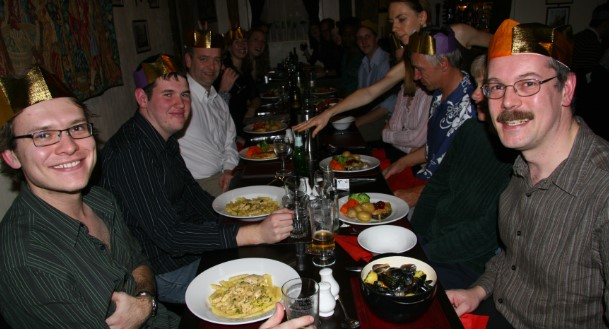

*Epidemiologists exposing themselves to multiple risk factors.*

Data adapted from Leman, Peter, and David Strachan. “A case-control study of food poisoning seen at an accident and emergency department.” *The Lancet* 358.9279 (2001): 387-388. link to full paper

Researchers conducted a study to investigate whether consumption of food cooked or prepared outside the home was associated with a greater risk of food poisoning. They enrolled (recruited) patients admitted to an emergency department of a large inner city hospital in London (England) over a 6 month period. They measured whether patients had eaten at a restaurant on the day or the day before presenting to the emergency department, by asking patients to complete a short questionnaire. Using medical records, the researchers identified which patients were admitted with food poisoning and which were not.

This is a classic case-control study design (more of that in a later session). The exposure variable is whether the patient ate in a restaurant in the previous 2 days. The outcome variable is whether the patient had food poisoning.

## 1.2 Contigency Tables

The sample of patients can, therefore, be broken down into four groups:

- those that did not eat out at a restaurant and did not get food poisoning (not exposed & no disease)
- those that did not eat out at a restaurant but did get food poisoning (not exposed & disease)
- those that did eat out at a restaurant but did not get food poisoning (exposed & no disease)
- those that did eat out at a restaurant and did get food poisoning (exposed & disease)

This information can be presented as a **contingency table**, which provide a simple way to look at the association between the two measured variables. Typically, both variables are binary (e.g., disease or no disease, exposed or not)

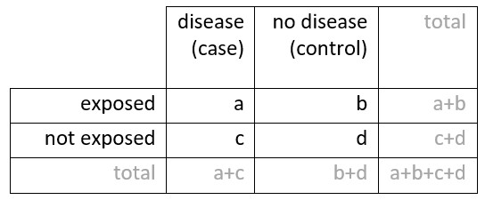

*An example contingency table*

## 1.3 Comparisons using relative risk and odds ratio

The relative risk (also called the risk ratio) is the ratio of risk of disease in one group (e.g., the exposed group) versus the risk of disease in the other group (e.g., unexposed group). The odds ratio (OR) is the ratio of odds of an event in one group compared to the odds of the event in the other group.

First, let’s familiarize ourselves with calculating the risk of a particular health outcome (in our example, food poisoning) among a group of individuals; this risk can also be called the **attack rate** or less commonly the incidence proportion. It is a simple probability or proportion.

Calculate:

1. the risk of a patient having food poisoning
2. the risk of a patient eating out at a restaurant AND having food poisoning
3. the risk of a patient not eating out at a restaurant AND having food poisoning

Which of these could be thought of as a baseline risk of food poisoning?

- What is the **relative risk** of having food poisoning for those that did eat out in a restaurant in the past 2 days compared to those who didn’t?

What does this ratio suggest to you? What would the ratio be if the risks were very similar?

The odds of an event happening are $p/(1-p)$ where $p$ is the probability of the event happening. The odds of having a specific disease is, therefore, the ratio between the probability of disease and the probability of no disease.

An **odds ratio** is simply the ratio of the odds of having the disease between two groups of individuals. Both relative risk and odds ratios are valid comparative measures of risk, but odds ratios are more widely used, partly because they naturally are estimated from logistic regression models (as we will see in a later session) but mostly because they don’t require the total number of exposed individuals to be measured, which is very difficult for diseases that are rare.

In the study, our working hypothesis is that the risk of disease (food poisoning) in the exposed group (restaurant goers) is greater than the risk of disease in the unexposed group.

- What is the **odds ratio** of having food poisoning for those that did eat out in a restaurant in the past 2 days compared to those who didn’t?

The researchers also provided the number of patients who had reported eating in different types of food outlet in the past 7 days, whether their occupation included handling food (“food handler”), and their sex. Note that the numbers are not mutually exclusive: individuals can report eating at more than one type of venue in the past 7 days; food handlers could be male or female.

| factor | type | controls | cases |
| --- | --- | --- | --- |
| Venue | Restaurant | 92 | 43 |
| Venue | Take-away | 97 | 58 |
| Venue | Canteen | 28 | 17 |
| Venue | Sandwich shop | 91 | 41 |
| Venue | Street vendor | 15 | 11 |
| Venue | Large function | 19 | 12 |
| Occupation | Food handler | 7 | 13 |
| Sex | Male | 95 | 58 |

- Calculate the odds ratio for each venue type and the whether they were a food handler or not. Think carefully about the two groups you are comparing when calculating each odds ratio.
- What does this tell us about the risk of getting food poisoning if you eat in a restaurant? Can we say if this more or less risky than eating from a take-away? What about eating at other venues?
- Which factors increase the risk of having food poisoning among the patients?
- Why may it be difficult to generalize from this study? (Hint: consider who these individuals are and how they came to be in the study)
- Is it a problem that we don’t know how the putative risk factors are distributed between individuals? How would you really want the data presented to you?

# 2 Understanding your sample

Epidemiological studies, by practical necessity, cannot recruit everyone in a population of interest into the study – it would be logistically problematic and exorbitantly expensive, and probably unethical. Statistical principles mean we don’t have to get information from everyone to be able to estimate statistical quantities and relationships between variables.

- What are the ethical considerations in under-sampling and over-sampling a population? (hint: think about statistical power)

Studies, therefore, often **sample** a subset of the population, with the aim that the sample is representative of the larger population they are drawn from. But, how can we be sure they are, and how do we try to detect bias that may have been generated by the recruitment process?

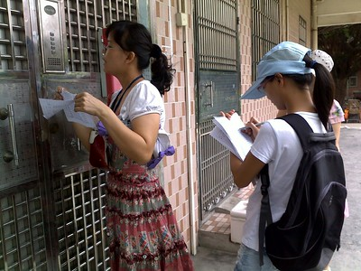

*A field team recruiting participants into a study in urban China*

## 2.1 Quantitative description of sampled individuals

One fundamental ‘diagnostic’ of epidemiological study sampling is to characterise the sample of individuals obtained, to relate it the population from which they are sampled (the target population), and to assess the biases that may be present in the sample. Particularly between ‘exposed’ and ‘not exposed’ groups.

Why would we wish to do this? One key reason is to assess whether any bias in the sampling may be considerable such that may invalidate associations that may be identified, and also to understand how generalisable any results may be.

### 2.1.1 Social contact survey data

This is data collected for a study on social contact rates conducted in 2009, which aimed to quantify the number of people encountered by participants during a single day.

Researchers conducted a cross-sectional survey of households and individuals within Great Britain (GB), asking for self-reported information regarding social encounters made during a specified day.

There were two recruitment arms to the study: a postal survey using a paper-based questionnaire sent to households in Great Britain (England, Wales and Scotland), and a web-based survey using an on-line questionnaire which was open for anyone to participate.

The postal survey was distributed to randomly selected households within GB from the post office address list database, with a total of 140,000 posted during 2009. Each survey had a randomized day of the week for which participants were asked to report their social contact during that day.

The study website hosting the on-line survey was further promoted *ad hoc* via university press releases, social networking sites and other media outlets (local radio, local and national newspapers). Participants for the on-line survey were asked to report their social contacts for “yesterday”.

Basic demographic data of participants were collected, including age and gender of participants, the number of people in their household and the first part of their home postcode, providing an approximate location.

The fields included in the summary data are:

- `id` – participant identifier (integer)
- `postal` – whether the survey was a paper-based postal questionnaire (0 = no, 1 = yes)
- `unmatched_postcode` – whether the home postcode entered by the participant could be matched to a known postcode (0 = no, 1 = yes)
- `web` – whether the survey was completed on-line (0 = no, 1 = yes)
- `age` – age, in years, of participant
- `date` – date questionnaire completed (and submitted, for on-line versions)
- `day_of_week` – the day of the week for which the contact information refers (0 = Monday, 1 = Tuesday, …, 6 = Sunday)
- `postcode` – imputed home postcode
- `sex` – sex of participant (0 = female, 1 = male, -1 = unspecified)
- `household.size` – number of household members, including the participant. (-1 = unspecified)
- `occupation` – categorical inferred occupation types. based on free-text occupation information provided by participants
- `total_contacts` – the total number of social contacts made during the day

### 2.1.2 Quantitive summaries of participant characteristics

Import the data into R/Rstudio, and familiarise yourself with the data structure.

```r
dat = read.csv(
  "data/social contact survey/scs.csv",
  na.strings=c("NA","-")
)
dim( dat )
```

```
## [1] 4217   12
```

```r
str( dat )
```

```
## 'data.frame':    4217 obs. of  12 variables:
##  $ id                : int  1 2 3 4 5 6 7 8 9 10 ...
##  $ postal            : int  1 1 1 1 1 1 1 1 1 1 ...
##  $ unmatched_postcode: int  0 0 0 0 0 0 0 0 0 0 ...
##  $ web               : int  0 0 0 0 0 0 0 0 0 0 ...
##  $ age               : int  51 62 36 27 35 61 41 73 78 54 ...
##  $ date              : chr  "28/05/2009" "28/05/2009" "28/05/2009" "28/05/2009" ...
##  $ day_of_week       : int  4 4 4 4 4 4 4 4 4 4 ...
##  $ postcode          : chr  "KT11 2JF" NA "GU34 2BG" "SW12 9HJ" ...
##  $ sex               : int  0 1 1 0 0 0 0 0 1 0 ...
##  $ household_size    : int  3 5 3 1 4 1 3 1 2 3 ...
##  $ occupation        : chr  "home" "public" "unknown" "office" ...
##  $ total_contacts    : int  106 20 7 13 44 30 16 1 2 27 ...
```

- Format the columns for age, sex, household size, day of the week in a sensible fashion.
- make a new column, with 5-year wide age groups, up to 90+ years old, ie “0-4”,“5-9”,…,“85-89”,“90+”. The `cut()` function will be useful.
- make a new column categorizing the implementation of the questionnaire, whether it was a paper postal survey, or an on-line survey. Use the columns `postal` and `web` to construct this.

“-1” in this data means the participant did not record anything for that particular data field. Is it always appropriate to convert these to NA in R?

You will need to format different columns depending on their data type. For instance, you can use `as.Date()` to convert the date column into a format that R can work with, and use `weekdays()` to extract the day of the week from a date. Categorical information is best handled as `factor` data type in R. Pay attention to the order of categories within a factor data type (see `levels()`), especially for ordinal data.

Here are some examples to get you going.

```r
dat$date = as.Date( dat$date, format="%d/%m/%Y" )
summary( dat$date ) # to check it worked ok
```

```
##         Min.      1st Qu.       Median         Mean      3rd Qu.         Max.
## "2009-04-28" "2009-06-08" "2009-06-08" "2009-07-28" "2009-06-08" "2010-09-20"
##         NA's
##        "113"
```

```r
# sex
  dat$sex = factor(
    dat$sex,
    levels=c(0,1,-1),
    labels=c("female","male","unknown")
  )
  table( dat$sex, useNA="always" )
```

```
##
##  female    male unknown    <NA>
##    2757    1393      67       0
```

```r
# day of the week
  dat$day_of_week = factor(
    dat$day_of_week,
    levels=c(0:6),
    labels=c("Monday","Tuesday","Wednesday","Thursday","Friday","Saturday","Sunday")
  )
  table( dat$day_of_week, useNA="always" ) # to check it worked ok
```

```
##
##    Monday   Tuesday Wednesday  Thursday    Friday  Saturday    Sunday      <NA>
##       559       629       668       612       673       580       496         0
```

Once you are happy that you’ve formatted the columns correctly, take a look at some of the distributions of these participant characteristics. `table()` and `barplot()` are useful exploratory tools in base R.

- What is the pattern of ages in the participants?
- Is there an equal sex ratio?
- What might this mean for our sample? How might we more accurately characterize and quantify them?

## 2.2 Assessing the representativeness of a sample

Once we have collected a sample of data from a population, we need to understand to the best of our ability whether the sample is representative of the population from which it is drawn. Ideally, we would select the sample at random – however, this is not always practical.

Census data strives to *not* be a sample of the population, but a close approximation to the true population. Of course, this is not always easy: some communities or sections of society, particularly transient communities or illegal workers, will be hard to reach, may not engage with instructions to complete census information, and so may get missed out. None-the-less, census information is often the best definitive source of population data for many countries.

### 2.2.1 Is the sample in the Social Contact Survey respresentative?

The survey was conducted in 2009 and 2010, so it is reasonable to compare the sample with 2011 UK census data, available to [download](https://www.ons.gov.uk/peoplepopulationandcommunity/populationandmigration/populationestimates/datasets/2011censuspopulationandhouseholdestimatesfortheunitedkingdom) as an xls file from the Office for National Statistics (ONS).

Office for National Statistics. [2011 Census: Population and Household Estimates for the United Kingdom](https://www.ons.gov.uk/peoplepopulationandcommunity/populationandmigration/populationestimates/datasets/2011censuspopulationandhouseholdestimatesfortheunitedkingdom)

**Table 1b** has the census measured population counts for Great Britain stratified by 5 year age bins and sex. To import this into R it is probably easiest to copy the specific table into a new worksheet in Excel, format it (remove blank rows, rename columns, *etc*), save it as a csv file, and import it into R as a new data object.

```r
census = read.csv("data/social contact survey/census.csv")
head( census )
```

```
##     Age Persons   Males Females
## 1   0-4 3790000 1939000 1851000
## 2   5-9 3406000 1743000 1663000
## 3 10-14 3551000 1818000 1732000
## 4 15-19 3870000 1976000 1894000
## 5 20-24 4171000 2100000 2071000
## 6 25-29 4183000 2084000 2098000
```

- Given the sample size, how many of each age group and sex would we expect, if the sample had been random?
- What does this tell us about potential bias in the data?
- Where do you think that bias may have arisen? (Hint: think about all the steps needed for someone to participate and submit a completed questionnaire)

You may find it helpful to known that, in R, `as.data.frame.matrix()` converts the output of `table()` to a `data.frame` object maintaining the table structure.

## 2.3 Assessing differences between groups of individuals

In epidemiological papers, there is usually a descriptive analysis of the attributes and properties of the two groups of individuals: those that have the disease (cases) and those that don’t (controls). This usually features early on in the results section and is often in a tabular format: the traditional ‘Table 1’ in epidemiological papers.

See, for example, Table 1 in this intriguing paper *“Metals and Breast Cancer Risk: A Prospective Study Using Toenail Biomarkers”* in the American Journal of Epidemiology (AJE), one of the top journals for epidemiology. [Link to paper](https://academic.oup.com/aje/article/190/11/2360/6322281). Best to look at the pdf for correct rendering of the table.

This type of table can also present some simple statistical evidence of any differences in characteristics between individuals with respect to the outcome of interest. The aim is to help the reader understand if there may be underlying differences other than the exposure of interest that could explain any difference in the risk or rate of the outcome between the groups.

Is this section we will prepare a ‘table 1’ as evidence to answer the question: **is there a difference between participants who completed the paper survey and those who completed it on-line?**

- Prepare a table suitable for a formal report, to show the number and percentage of participants stratified by survey method, and further stratified by age group, sex, and day of the week

To construct this type of Table 1, it is best to break it down to it’s separate components and stages.

1. Consider the categorical variables age group, sex, and day of the week in turn, and generate a table for each with the outcome (on-line or postal).
2. Examine each table for differences between the two groups, and also conduct a chi-squared test for difference (`chisq.test()` in R).
3. ‘Stack’ the tables into a single data object, and include the p value for each chi squared test. You can export this from R as a csv file (`write.csv()`) and tidy the table up and format it in excel.
4. Produce a publication-worthy Table 1!
5. What does it tell us about who participated via the two methods? Does it give us insight into possible barriers for participation?

We could, of course, consider other variables in this table. **We can’t include anything we haven’t measured though**. There are ways to make publishable tables (html, latex etc) from R using packages, which you are of course free to consider, but sooner or later you are going to need to produce a table in Word for submission to a journal, and keeping things simple really helps then!

Some basic table formatting guidance:

- Always include a legend
- Think carefully about the layout: is it logically consistent?
- Numbers are better presented right aligned
- Pick a sensible level of precision for numbers (e.g., 3.142 instead of 3.14159265358979323846). `round()` and sprintf()` functions in R are very helpful here!
- Be consistent with precision within a variable
- Text is better left aligned
- Use indentation to group variables or categories together

You should aim to get something that looks like this. I’ve left the grid cells visible so you can see the merging and alignment formatting better. Remember, generally speaking, numerical data is best aligned to the right (for clarity of reading).

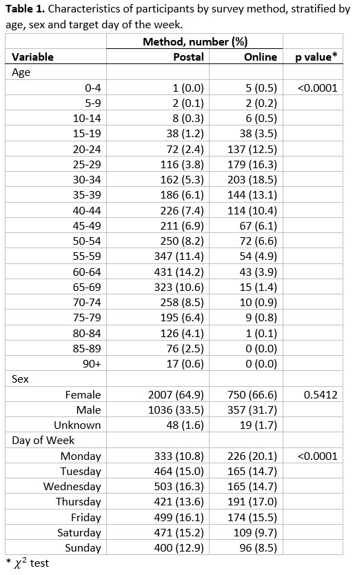

*The resulting Table 1.*

Note, that this is only looking at differences by one variable at a time.

- What statistical approach could consider if there are differences in age, sex and day of the week between the two groups, simultaneously?